# Mutual Rank eQTL overlap

## Background

Rob Baker et al fit growth parameters to B. rapa growth data and then used those to do function-value-trait QTL mapping.

I used those same parameters and queried a mutual rank (MR) gene expression network to find genes that were in a networks associated with these growth paramters. This was done separately for the CR and UN environments. I looked for overlap between those MR-associated genes and growth parameters.

The goal now is to find the trans eQTL for each of the MR-growth associated genes and ask if the trans eQTL overlap with the growth/function-value QTL. I think I am only going to take the top eQTL for each chromosome (seems reasonable…pretty much one peak per chromosome).

**This script uses CIM to find eQTL for MR UN network genes.**

## Load the libraries and data

Libraries

```r
library(qtl)
library(tidyverse)
library(snowfall)
```

MR genes from UN

```r
MR_UN_genes <- read_csv("../output/MR_UN_graphs_node_annotation_2012.csv") %>%
  filter(MR_Cutoff <= 50, !duplicated(name)) %>%
  mutate(pos=floor((start+end)/2)) %>%
  select(MR_Cutoff,name, transcript_chrom=chrom, transcript_pos=pos)
MR_UN_genes
```

| MR_Cutoff | name | transcript_chrom | transcript_pos |
| --- | --- | --- | --- |
| 10 | Bra038899 | A01 | 15642378 |
| 10 | Bra012899 | A03 | 21659600 |
| 20 | Bra011761 | A01 | 689820 |
| 20 | Bra006755_Bra006756 | A03 | 4922185 |
| 20 | Bra022867 | A03 | 7482825 |
| 20 | Bra023009 | A03 | 8220061 |
| 20 | Bra025790 | A06 | 7732662 |
| 20 | Bra036465 | A07 | 226259 |
| 20 | Bra013959 | A08 | 4966646 |
| 20 | Bra017468 | A09 | 13487566 |

[output cut: 46 more lines]

expression data

```r
MR_UN_2012_expression <- read_csv("../output/MR_UN_2012_gene_expression.csv")
MR_UN_2012_expression
```

| .id | MR_Cutoff | trt | name | chrom | start | end | subject | AGI | At_symbol | At_description | perc_ID | aln_length | mismatch | gap_open | qstart | qend | sstart | send | eval | score | RIL_1 | RIL_103 | RIL_104 | RIL_113 | RIL_115 | RIL_12 | RIL_123 | RIL_124 | RIL_131 | … |
| --- | --- | --- | --- | --- | --- | --- | --- | --- | --- | --- | --- | --- | --- | --- | --- | --- | --- | --- | --- | --- | --- | --- | --- | --- | --- | --- | --- | --- | --- | --- |
| blup.mr.graph.UN.2012.10 | 10 | UN | Bra038899 | A01 | 15641416 | 15643341 | AT3G51430.1 | AT3G51430 | SSL5;YLS2 | Although this enzyme is predicted to encode a strictosidine synthase (SS), it lacks a conserved catalytic glutamate residue found in active SS enzymes and it is not expected to have SS activity. | 81.047 | 1108 | 203 | 5 | 297 | 1402 | 1103 | 1 | 0.00e+00 | 1036.0 | 2.3555731 | 2.3995530 | 0.6272034 | 3.10981819 | 2.3873724 | 2.6718518 | 3.0320003 | 2.38520918 | 3.0439922 | … |
| blup.mr.graph.UN.2012.10 | 10 | UN | Bra012899 | A03 | 21658875 | 21660326 | AT3G50440.1 | AT3G50440 | ATMES10;MES10 | Encodes a protein shown to have methyl jasmonate esterase activity in vitro. This protein does not act on methyl IAA, MeSA, MeGA4, or MEGA9 in vitro. | 85.797 | 859 | 118 | 3 | 127 | 982 | 865 | 8 | 0.00e+00 | 989.0 | 3.2363688 | 3.0164998 | 3.4824033 | 2.69574139 | 3.0988207 | 3.9880230 | 2.8507403 | 3.81665737 | 2.8614715 | … |
| blup.mr.graph.UN.2012.20 | 20 | UN | Bra011761 | A01 | 688837 | 690803 | AT4G37430.1 | AT4G37430 | CYP81F1;CYP91A2 | Encodes a member of the CYP81F cytochrome P450 monooxygenase subfamily. | 82.710 | 1498 | 251 | 4 | 188 | 1678 | 1497 | 1 | 0.00e+00 | 1523.0 | 1.7448108 | 1.0120729 | 1.2793765 | 2.16579488 | 1.8358756 | 4.2386537 | 2.8963044 | 0.78055708 | 2.7124916 | … |
| blup.mr.graph.UN.2012.20 | 20 | UN | Bra006755_Bra006756 | A03 | 4918760 | 4925611 | NA | NA | NA | NA | NA | NA | NA | NA | NA | NA | NA | NA | NA | NA | 2.8963902 | 3.3746868 | 1.6999337 | 3.20460173 | 4.7423746 | 4.8410522 | 3.4564075 | 1.53450456 | 2.7769634 | … |
| blup.mr.graph.UN.2012.20 | 20 | UN | Bra022867 | A03 | 7480730 | 7484921 | AT2G31810.1 | AT2G31810 | NA | NA | 87.221 | 1479 | 150 | 5 | 161 | 1603 | 1 | 1476 | 0.00e+00 | 1828.0 | 4.1961389 | 4.7575146 | 4.7679095 | 5.37269510 | 4.5781482 | 4.4410897 | 5.4261931 | 5.12668141 | 5.0096204 | … |
| blup.mr.graph.UN.2012.20 | 20 | UN | Bra023009 | A03 | 8219083 | 8221040 | AT2G43590.1 | AT2G43590 | NA | NA | 79.128 | 757 | 140 | 5 | 1 | 745 | 795 | 45 | 0.00e+00 | 646.0 | 5.3677665 | 5.5593533 | -1.5047131 | 0.70679378 | 1.9988463 | 5.4544920 | 0.1217901 | 0.89626454 | 1.6815925 | … |
| blup.mr.graph.UN.2012.20 | 20 | UN | Bra025790 | A06 | 7732370 | 7732955 | AT1G20070.1 | AT1G20070 | NA | NA | 82.149 | 549 | 86 | 4 | 177 | 719 | 582 | 40 | 1.87e-153 | 542.0 | 3.1194514 | 3.3690249 | 1.4589272 | 3.74135122 | 2.3299455 | 4.1225285 | 4.8537815 | 2.00940518 | 4.1709104 | … |
| blup.mr.graph.UN.2012.20 | 20 | UN | Bra036465 | A07 | 224092 | 228427 | AT2G20340.1 | AT2G20340 | AAS;AtAAS | NA | 87.361 | 1440 | 182 | 0 | 1 | 1440 | 1473 | 34 | 0.00e+00 | 1777.0 | 2.6419366 | 0.5482333 | 1.6266701 | 1.95484372 | 2.7764441 | 0.5857240 | 1.0092812 | 1.31631645 | 0.1223920 | … |
| blup.mr.graph.UN.2012.20 | 20 | UN | Bra013959 | A08 | 4964613 | 4968680 | AT5G17680.1 | AT5G17680 | NA | NA | 88.209 | 2044 | 223 | 3 | 21 | 2064 | 33 | 2058 | 0.00e+00 | 2603.0 | -2.8822025 | -3.7894074 | -2.7284686 | 1.14639124 | -4.0953276 | -3.2959422 | 0.3467971 | -2.87517296 | 1.2984734 | … |
| blup.mr.graph.UN.2012.20 | 20 | UN | Bra017468 | A09 | 13486185 | 13488948 | AT5G47730.1 | AT5G47730 | NA | NA | 90.220 | 1002 | 97 | 1 | 583 | 1584 | 1 | 1001 | 0.00e+00 | 1362.0 | 3.1413731 | 3.8689498 | 2.2749575 | 2.76763089 | 2.7615332 | 2.7211723 | 3.4927912 | 2.80600216 | 3.7317560 | … |

[output cut: 46 more lines]

confirm that we have the same genes in each:

```r
setdiff(MR_UN_2012_expression$name, MR_UN_genes$name)
```

```
character(0)
```

```r
setdiff(MR_UN_genes$name, MR_UN_2012_expression$name)
```

```
character(0)
```

## CIM mapping

set up data

```r
cross.all <- read.cross("csvsr",
                       genfile="../input/snp_map_rqtl_Mbp_ref1.5.2_cross_output_gen.csv" ,
                           phefile="../output/MR_UN_genes_qtl_input_2012.csv",
                           genotypes=c("AA","BB"), na.strings = "-")
```

```
29 individuals with genotypes but no phenotypes
    RIL_234|RIL_311|RIL_5|RIL_18|RIL_20|RIL_29|RIL_41|RIL_44|RIL_52|RIL_56|RIL_68|RIL_78|RIL_88|RIL_194|RIL_195|RIL_231|RIL_236|RIL_261|RIL_278|RIL_307|RIL_312|RIL_328|RIL_331|RIL_348|RIL_352|RIL_366|RIL_367|RIL_368|RIL_370
```

```
 --Read the following data:
     151  individuals
     1451  markers
     57  phenotypes
 --Cross type: bc
```

```r
class(cross.all)[1] <- "riself"
cross.all <- jittermap(cross.all)
cross.all
```

```
  This is an object of class "cross".
  It is too complex to print, so we provide just this summary.
    RI strains via selfing

    No. individuals:    151

    No. phenotypes:     57
    Percent phenotyped: 81.1

    No. chromosomes:    10
        Autosomes:      A01 A02 A03 A04 A05 A06 A07 A08 A09 A10

    Total markers:      1451
    No. markers:        163 119 207 100 84 158 160 77 216 167
    Percent genotyped:  82
    Genotypes (%):      AA:47.2  BB:52.8
```

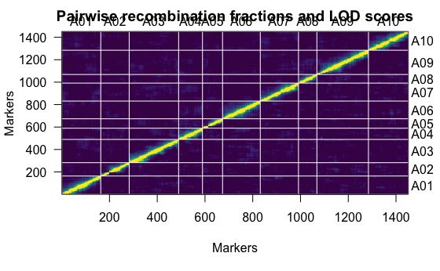

```r
cross.all <- est.rf(cross.all)
plotRF(cross.all)
```

```r
cross.all <- calc.errorlod(cross.all, error.prob=0.001)
cross.all <- sim.geno(cross.all,step=2)
```

```r
system.time(scanone_MR <- scanone(cross.all, pheno.col = 2:ncol(cross.all$pheno),
             method = "imp", use = "all.obs"))
```

```
Dropping 29 individuals with missing phenotypes.
```

```
   user  system elapsed
  1.507   0.075   1.609
```

```r
system.time(scanone_MR_cim <- lapply(2:ncol(cross.all$pheno),function(pheno) cim(cross.all, pheno.col = pheno,
             method = "imp")))
```

```
   user  system elapsed
 25.586   1.396  27.602
```

```r
scanone_MR_cim <- do.call(c,scanone_MR_cim)
colnames(scanone_MR_cim)[-1:-2] <- colnames(cross.all$pheno)[-1]
```

```r
#the built-in parallel method for scanone is hanging, so roll my own
sfInit(parallel = TRUE, cpus = 4)
```

```
snowfall 1.84-6.1 initialized (using snow 0.4-3): parallel execution on 4 CPUs.
```

```r
sfLibrary(qtl)
```

```
Library qtl loaded.
```

```
Library qtl loaded in cluster.
```

```r
sfExport("cross.all")

set.seed(12345)
system.time(permtest <- sfLapply(1:4,function(x) scanone(cross.all, method = "imp",
                       pheno.col = 2:ncol(cross.all$pheno),
                       n.perm = 250)))
```

```
   user  system elapsed
  0.498   0.536 512.537
```

```r
sfStop()
```

```
Stopping cluster
```

```r
permtest <- do.call(rbind,permtest)

attr(permtest,"method") <- "imp"
attr(permtest,"model") <- "normal"
attr(permtest,"type") <- "riself"
attr(permtest,"class") <- c("scanoneperm","matrix")

permtest[1:5,1:5]
```

```
  Bra038899 Bra012899 Bra011761 Bra006755_Bra006756 Bra022867
1  2.339983  2.935348  1.843459            1.330786  2.207519
2  3.145149  1.710314  1.989159            2.448238  2.649709
3  1.626988  2.936351  2.838026            2.580297  2.278468
4  2.260187  1.772503  1.547539            2.266937  2.116558
5  1.670295  1.872055  1.786209            2.003068  1.638696
attr(,"class")
[1] "scanoneperm" "matrix"
attr(,"method")
[1] "imp"
attr(,"model")
[1] "normal"
attr(,"type")
[1] "riself"
```

```r
dim(permtest)
```

```
[1] 1000   56
```

```r
sfInit(parallel = TRUE, cpus = 4)
```

```
snowfall 1.84-6.1 initialized (using snow 0.4-3): parallel execution on 4 CPUs.
```

```r
sfLibrary(qtl)
```

```
Library qtl loaded.
```

```
Library qtl loaded in cluster.
```

```r
sfExport("cross.all")

system.time(permtest.cim <- sfSapply(2:ncol(cross.all$pheno),
                                     function(pheno) cim(cross.all,
                                                         pheno.col = pheno,
                                                         method = "imp",
                                                         n.perm=1000))
)
```

```
     user    system   elapsed
   57.838    32.283 38019.243
```

```r
sfStop()
```

```
Stopping cluster
```

```r
attr(permtest.cim,"class") <- "scanoneperm"

colnames(permtest.cim) <- colnames(cross.all$pheno)[-1]
```

```r
lod.thrs <- summary(permtest, 0.05)
lod.thrs
```

```
LOD thresholds (1000 permutations)
   Bra038899 Bra012899 Bra011761 Bra006755_Bra006756 Bra022867 Bra023009 Bra025790 Bra036465
5%      3.17      3.33       3.1                3.23       3.3      3.35      3.13      3.12
   Bra013959 Bra017468 Bra008566 Bra008575 Bra008577 Bra008637 Bra008840 Bra008859 Bra037542
5%      3.26      3.22      3.14      3.23      3.17      3.37      3.28      3.27      3.19
   Bra028216 Bra025497 Bra005332 Bra018973 Bra025250 Bra037847 Bra026943 Bra002411 Bra008684
5%      3.42      3.24      3.37      3.25      3.26      3.29      3.34      3.17      3.18
   Bra008734 Bra008750 Bra039532 Bra100024 Bra021591 Bra022535 Bra008162 Bra029099 Bra029100
5%      3.31      3.24      3.24      3.11      3.17      3.12      3.17      3.37      3.21
   Bra029111 Bra022924 Bra023056 Bra023094 Bra014655 Bra039792 Bra019796 Bra026068 Bra024437
5%      3.28      3.19      3.26      3.19      3.05       3.2      3.22       3.1      3.21
   Bra024934 Bra013968 Bra101871 Bra029573 Bra002619 Bra002290 Bra002255 Bra102309 Bra008635
5%      3.24      3.27      3.18      3.19      3.14      3.18      3.18       3.3      3.33
   Bra008711 Bra008797 Bra008931
5%      3.35      3.29      3.17
```

```r
mean(lod.thrs)
```

```
[1] 3.229141
```

```r
sd(lod.thrs)
```

```
[1] 0.08098373
```

```r
lod.thrs.cim <- summary(permtest.cim, 0.05)
lod.thrs.cim
```

```
LOD thresholds (1000 permutations)
   Bra038899 Bra012899 Bra011761 Bra006755_Bra006756 Bra022867 Bra023009 Bra025790 Bra036465
5%      4.56      4.48      4.58                4.61      4.55      4.41      4.51      4.59
   Bra013959 Bra017468 Bra008566 Bra008575 Bra008577 Bra008637 Bra008840 Bra008859 Bra037542
5%      4.56      4.54      4.69      4.59       4.6      4.63      4.67      4.62      4.69
   Bra028216 Bra025497 Bra005332 Bra018973 Bra025250 Bra037847 Bra026943 Bra002411 Bra008684
5%      4.67      4.59      4.64      4.56      4.43       4.4      4.46      4.58      4.74
   Bra008734 Bra008750 Bra039532 Bra100024 Bra021591 Bra022535 Bra008162 Bra029099 Bra029100
5%      4.57       4.6      4.69      4.53      4.65      4.52      4.52      4.55      4.66
   Bra029111 Bra022924 Bra023056 Bra023094 Bra014655 Bra039792 Bra019796 Bra026068 Bra024437
5%      4.61      4.52       4.6      4.65      4.61      4.67      4.44      4.67      4.57
   Bra024934 Bra013968 Bra101871 Bra029573 Bra002619 Bra002290 Bra002255 Bra102309 Bra008635
5%      4.56      4.65      4.52      4.47      4.54      4.33      4.58      4.56      4.71
   Bra008711 Bra008797 Bra008931
5%      4.55      4.55      4.51
```

```r
mean(lod.thrs.cim)
```

```
[1] 4.573236
```

```r
sd(lod.thrs.cim)
```

```
[1] 0.08330505
```

```r
save(cross.all,scanone_MR,scanone_MR_cim,permtest,permtest.cim,lod.thrs,lod.thrs.cim,file = "../output/scanone-MRgene-qtl_2012.RData")
```